# Gündelik Yaşamda Etkileşim(ler)

[figure not shown]

Leap into the Void, Yves Klein (1960)

> Riezler’in de dediği gibi, elimizde bir yüzünde hayranlık, diğer yüzünde ise utanç olan bir toplumsal madalyon var. Seyirci performansın ardında saklı gizemler ve güçler olduğunu, oyuncu ise önemli sırlarının sıradan olduğunu hisseder. Sayısız halk masalından ve kabul törenlerinden de görebileceğimiz gibi, genelde gizemin ardındaki gerçek sır aslında ortada bir gizem olmamasıdır. Asıl sorun bunu seyircinin de öğrenmesini önlemektir.  
> – Erving Goffman, *Gündelik Yaşamda Benliğin Sunumu*, 2018 (1959)

## Genel Bilgiler

**Dersin kodu ve adı**: Gündelik Yaşamda Etkileşim  
**Ders günü/saati ve yeri**: Cuma 14:00-16:00 & F1-09  
**Dersle ilgili görüşme saati**: Perşembe 09:15-10:15  
**E-posta:** tahirenes.gedik@ikcu.edu.tr

## Dersin Amacı ve İçeriği

Dersin amacı, öğrencilerin gündelik yaşamda ilişkileri belirleyen etkileşim düzenini anlamalarını sağlamaktır. Bu doğrultuda, benlik, toplumsal roller ve kimlik gibi kavramlar üzerinde durulacaktır. Bunun yanında öğrenciler, belli durumlarda ortaya çıkan gündelik toplumsal ilişkileri örneklerle çözümleme fırsatına sahip olacaktır. Dersin sonunda öğrenciler içinde yaşadıkları etkileşim düzenine dair özdüşünümsel bir yaklaşım geliştirebilecektir.

### Önerilen Ders Kitabı:

Bu dersin zorunlu bir ders kitabı bulunmamaktadır. Ancak öğrenciler derste işlenen kavramları tanımak için aşağıdaki kitaptan yararlanabilirler.

- Hewitt, John P. and David Shulman. 2019. *Benlik ve Toplum: Sembolik Etkileşimci Sosyal Psikoloji*. İstanbul: Bilge Kültür Sanat.

## Dersin İşleniş Biçimi, Kurallar ve Değerlendirme Ölçütleri

#### Yoklama ve Derse Katılım:

Öğrencilerin derse gelmesi **zorunludur** (devam zorunluluğu ile ilgili haklarınızı öğrenmek için lisans yönetmeliğine bakınız). Öğrencilerin derse katılımı ve konuları takip edebilmeleri için okumaları zamanında yapmaları gerekmektedir.

#### Vize ve Final Sınavları:

Vize ve final sınavları yazılı bölümlerden oluşmaktadır. Sınav tarihlerinin duyurusu dönem içinde yapılacaktır. Öğrenciler sınavda okumalardan ve derste yapılan tartışmalardan sorumludur. Sınavların kapsamı sınav öncesi öğrencilere duyurulacaktır.

#### Sınıf İçi Etkinlikler

Dersin ilerleyen haftalarında sınıf içi grup çalışmaları yapılacaktır. Bu çalışmalardan not alabilmeleri için öğrencilerin derse katılımları gerekmektedir.

#### Sınıfta Davranış Kuralları:

Sınıfta yapılan tartışmalar sırasında öğrencilerin birbirlerine karşı saygılı olması, gerginliğe sebep olacak davranışlardan kaçınması dersin rahat ve huzurlu işlenmesi için önemlidir.

Derste cep telefonu, dizüstü bilgisayar vb. elektronik cihazların kullanımı yasaktır (herhangi bir sebeple bu cihazları kullanmak zorunda olan öğrenciler gerekli belgelerle birlikte öğretim görevlisiyle iletişime geçmelidir). Sınıfta bir etkinlik için kullanılmaları gerektiğinde öğrenciler öğretim görevlisi tarafından bilgilendirilecektir.

#### Not Sistemi

Üniversite Seçmeli Havuz Dersleri Hazırlama ve Uygulama Esasları için [tıklayınız](https://dis.ikcu.edu.tr/Share/63F5B3FA632BCB869B853C20813F3E31). Esaslara göre:

| Puan | Not | Katsayı |
| --- | --- | --- |
| 88-100 | AA | 4.00 |
| 81-87 | BA | 3.50 |
| 74-80 | BB | 3.00 |
| 67-73 | CB | 2.50 |
| 60-66 | CC | 2.00 |
| 53-59 | DC | 1.50 |
| 46-52 | DD | 1.00 |
| 39-45 | FD | 0.50 |
| 0-38 | FF | 0.00 |

###### Nasıl E-posta Yazılır?

Dersle ilgili sorularınız için e-posta yoluyla iletişime geçebilirsiniz. E-posta yazarken dikkat etmeniz gereken bazı noktalar bulunmaktadır:

- Anlaşılır ve açıklayıcı bir konu başlığı bulun. E-posta metnini konuya yazmayın.
- Uygun bir hitapla başlayın.
- Konuya doğrudan giriş yapın. Açık bir şekilde sorunuzu yazın ve gereksiz yere e-postayı uzatmayın.
- Uygun bir ifadeyle e-postayı bitirin. Sonuna adınızı ve soyadınızı yazmayı unutmayın.

Bu adımları takip etmemeniz halinde e-postanıza cevap alamazsınız.

# Konular

| Haftalar | Konular* |
| --- | --- |
| 1.Hafta | Ders tanıtımı |
| 2.Hafta | Giriş: Benlik’in ortaya çıkışı |
| 3. Hafta | Sembolik Etkileşim ve Temel Kavramlar |
| 4. Hafta | [Benlik ve Kimlik](https://tegedik.github.io/ghe1/) |
| 5. Hafta | Gerçekliğin Toplumal İnşası (?) |
| 6. Hafta | Sosyal Düzeni Anlamak ve Kurmak |
| 7. Hafta | Gündelik Yaşamda Benliğin Sunumu: Performanslar |
| 8. Hafta | **Vize Haftası** |
| 9. Hafta | Etkileşim Ritüelleri |
| 10. Hafta | Kapatma Kurumları |
| 11. Hafta | Türkiye’de Toplumsal Benlik |
| 12. Hafta | Toplumsal durumları örneklerle çözümleme I |
| 13. Hafta | Toplumsal durumları örneklerle çözümleme II |
| 14. Hafta | Toplumsal durumları örneklerle çözümleme III |
| 15. Hafta | Toplumsal durumları örneklerle çözümleme IV |

***Değişiklikler yapılabilir.**

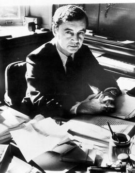

Erving Goffman (1922-1982)

# Önerilen Okumalar

Önerilen diğer ders kaynakları (kitaplar):

- Collins, Randall. 2004. *Interaction Ritual Chains.* Princeton and Oxford: Princeton University Press.
- Crawford, Elizabeth A. *and Katherine B. Novak. 2018. Individual and Society: Sociological Social Psychology.* New York and London: Routledge.
- Goffman, Erving. 1959. *The Presentation of Self in Everyday Life.* New York: Anchor Books Doubleday. [Goffman, Erving. 2018. *Günlük Yaşamda Benliğin Sunumu*. İstanbul: Metis.]
- Goffman, Erving. 1967. *Interaction Ritual: Essays on Face-to-Face Behavior*. New York: Pantheon Books. [Goffman, Erving. 2017. *Etkileşim Ritüelleri: Yüz Yüze Davranış Üzerine Denemeler.* Ankara: Heretik Yayınları.]
- Goffman, Erving. 1971. *Relations in Public: Microstudies of the Public Order.* New York: Basic Books. [Goffman, Erving. 2017. *Kamusal Alanda İlişkiler: Toplu Yaşamın Mikro İncelemeleri.* Ankara: Heretik  
  Yayınları.]

## Online Kaynaklar

- [Interactionist Sociology](http://cdclv.unlv.edu/archives/interactionism/)
- [Erving Goffman Archives](http://cdclv.unlv.edu/ega/)
- [Symbolic Interaction](https://onlinelibrary.wiley.com/journal/15338665)

[Tahir Enes Gedik](https://tegedik.netlify.com/)

Cuma, 14:00-16:00